# markov-chains-differential-expression-analysis

Lubna Al Amri

2024-12-03

## # Part 1

# Simulation Questions

## Comment Code

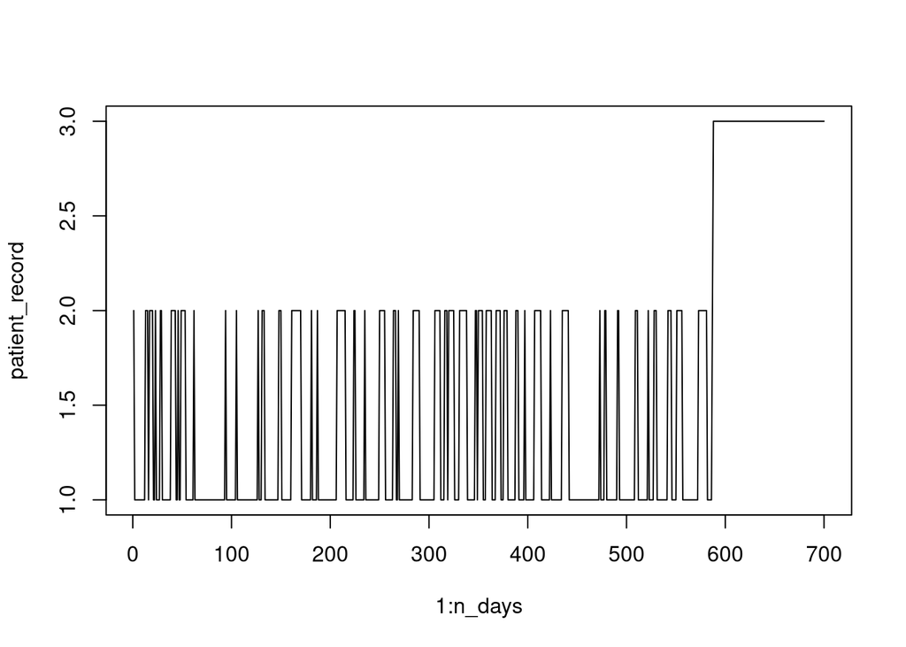

```r
set.seed(42) #setting a seed to 42. This helps with reproducibility

# Defining transition probabilities calculated from the markov chain
a <- 0.8999 # Probability of staying healthy
b <- 0.69 #Probability of staying sick
n_days <- 700 # Number of days we are simulating

#creating transition probability matrix
# Rows contain : current state ( 1st row = Healthy, 2nd row = Sick , 3rd row = Dead)
# Columns contain : the probability of transitioning to each different state
transition_matrix <- matrix(c(a, 0.1, 0.0001,   #Transitioning from Healthy
                              0.3, b, 0.01,     # Transitioning from Sick
                              0, 0, 1),         # Transitioning from Dead
                              nrow=3, ncol=3, byrow=TRUE)
# Setting starting state as Healthy (state 1)
state <- 1

# Creating a vector to store patient states daily
patient_record <- rep(0, n_days)

#Simulating patient state changes for each day
for (day in 1:n_days) {
  pr <- transition_matrix[state, ]   #Transitioning probabilities for the current state

#Randomly sampling next state based on transition probabilities
  state <- sample(c(1:3), size = 1, prob = pr)
  patient_record[day] <- state  #recording the state for this day
}

#Plotting patient state over time
plot(1:n_days, patient_record, "l")
```

## Extending the Markov Chain

The Markov Chain will be extended to include the state $S_H$ (Sick in the hospital) and the transition probabilities between the states. The values of a,b, and c are worked out. A plot of the different states in a single patient is generated.

```r
set.seed(42)

# defining trnasition probabilities that were calculated from Markov chain
a <- 0.899 # prob. of staying healthy
b <- 0.29 # prob. of staying sick (not hospitalized)
c <- 0.55  # prob. of staying sick in hospital (state 3)

n_days <- 700 #number of days to stimulate


#creating a probability matrix with 4 different states.
#Stats : 1=Healthy, 2=Sick, 3=Hospital, 4=Dead
transition_matrix2 <- matrix(c(
    a,    0.1,   0,     0.0001,  # Transitioning from Healthy
    0.3,  b,     0.4,   0.01,    # Transitioning from Sick
    0.2,  0.2,   c,     0.05,    # Transitioning from Hospital
    0,    0,     0,     1        # Transitioning from Dead
), nrow=4, ncol=4, byrow=TRUE)

print(transition_matrix2)
```

```
##       [,1] [,2] [,3]  [,4]
## [1,] 0.899 0.10 0.00 1e-04
## [2,] 0.300 0.29 0.40 1e-02
## [3,] 0.200 0.20 0.55 5e-02
## [4,] 0.000 0.00 0.00 1e+00
```

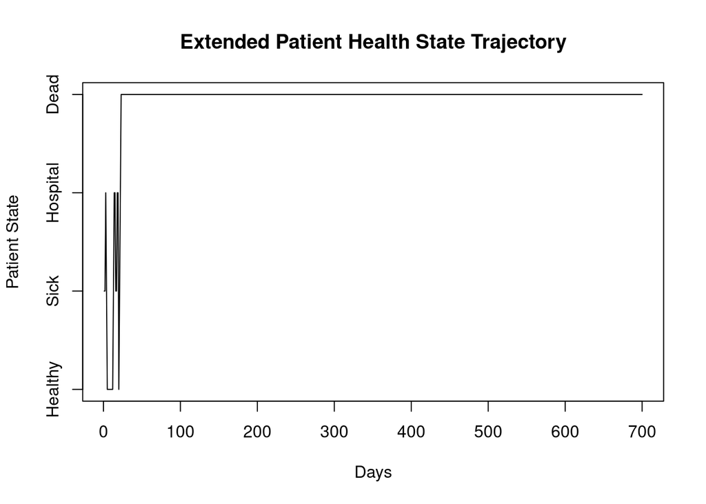

```r
#setting starting state as Healthy (state 1)
state <- 1

#creating a vector that stores daily patient states
patient_record <- numeric(n_days)

#creating a loop that stimulates patient state changes for each day
for (day in 1:n_days) {
  pr <- transition_matrix2[state, ] #getting transition probabilities for current state

  state <- sample(c(1:4), size = 1, prob = pr)
  patient_record[day] <- state
}


# Plot patient state trajectory over time
plot(1:n_days, patient_record, type="l",
     xlab="Days",
     ylab="Patient State",
     main="Extended Patient Health State Trajectory",
     ylim=c(1,4),
     yaxt="n")  # Suppress default y-axis

# Create custom y-axis with state labels
axis(2, at=1:4, labels=c("Healthy", "Sick", "Hospital", "Dead"))
```

## Repeating the Simulation

A repetition of the four-state Markov Chain is carried out for 1000 patients. A plot displays how long a patient spends in each state on average. The average time spent in each state is calculated for the 1000 patients.

```r
set.seed(42)

# defining transition probabilities that were calculated from Markov chain
a <- 0.899 # prob. of staying healthy
b <- 0.29 # prob. of staying sick (not hospitalized)
c <- 0.55  # prob. of staying sick in hospital (state 3)

#defining simulation parameters
n_days <- 700 #number of days to stimulate
n_patients <- 1000

#creating a probability matrix with 4 different states.
#Stats : 1=Healthy, 2=Sick, 3=Hospital, 4=Dead
transition_matrix2 <- matrix(c(
    a,    0.1,   0,     0.0001,  # Transitioning from Healthy
    0.3,  b,     0.4,   0.01,    # Transitioning from Sick
    0.2,  0.2,   c,     0.05,    # Transitioning from Hospital
    0,    0,     0,     1        # Transitioning from Dead
), nrow=4, ncol=4, byrow=TRUE)

print(transition_matrix2)
```

```
##       [,1] [,2] [,3]  [,4]
## [1,] 0.899 0.10 0.00 1e-04
## [2,] 0.300 0.29 0.40 1e-02
## [3,] 0.200 0.20 0.55 5e-02
## [4,] 0.000 0.00 0.00 1e+00
```

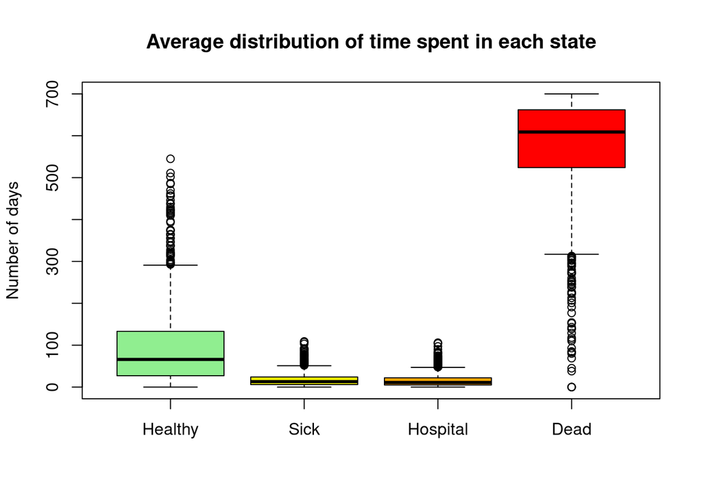

```r
#setting starting state as Healthy (state 1)
state <- 1

#creating a vector that stores daily patient states
all_patient_records <- matrix(0, nrow=n_patients, ncol=n_days)

#creating a loop that stimulates for each patient
for (patient in 1:n_patients) {
  state <- 1 #starting healthy
  patient_record <- numeric(n_days)


  for (day in 1:n_days) {
      pr <- transition_matrix2[state, ]
      state <- sample(1:4, size=1, prob=pr)
      patient_record[day] <- state
  }


  all_patient_records[patient,] <- patient_record
}

# Calculating time spent in each state for each patient
time_in_states <- matrix(0, nrow=n_patients, ncol=4)
for(patient in 1:n_patients) {
    for(state in 1:4) {
        time_in_states[patient,state] <- sum(all_patient_records[patient,] == state)
    }
}

#calculating average time in each state
avg_time_in_states <- colMeans(time_in_states)
names(avg_time_in_states) <- c("Healthy", "Sick", "Hospital", "Dead")

## creating a box plot

boxplot(time_in_states,
        names=c ("Healthy", "Sick", "Hospital", "Dead"),
        main="Average distribution of time spent in each state",
        ylab="Number of days",
        col=c("lightgreen", "yellow", "orange", "red"))
```

```r
#print average times
print("Average days spent in each state:")
```

```
## [1] "Average days spent in each state:"
```

```r
print(round(avg_time_in_states, 2))
```

```
##  Healthy     Sick Hospital     Dead
##    95.74    18.16    16.30   569.80
```

From the results we see that the average time spent :

- *Healthy*: 95.74 days. Patients start healthy and remain in this state for approximately 3 months.
- *Sick* : 18.16 days. Patients experience short periods of illness.
- *Hospital*: 16.30 days. This is similar to the sick state which suggests quick transitions.
- *Dead*: 569.80 days. This is the highest duration due to the fact that it is an absorbing state ( once the person is dead, they will remain dead).

The boxplot results:

Each box represents the distribution of time spent in that particular state across 1000 patients. Horizontal line inside each box is the median. In the healthy state, the moderate spread is around 96 days and there are many outliers above which suggests that some patients stayed healthy longer.

The dead state has the largest box illustrating high variability. The high median reflect the nature of the absrobing state. The lower outliers represents patients who died early.

## Commenting on The Results

Changing the starting state would have an impact on the simulated results. If the simulation starts in the Sick at Home (S0) state it would lead to a faster progression to the Hospitalized (SH) and Dead (D) states, this is because the patient has a higher immediate risk to move to more sever conditions.

If the stimulation starts at the Hospitalized (SH) state, this will cause the patient to transition to the Dead state very quickly with very little time spent in other states.

If the starting state is Dead (D), then this means that the patient will remain in that state for the remainder of the simulation.

From this, it is seen that the initial selected state can have a significant influence on the overall health trajectory shown in the simulation.

# Data Analysis

## Adding comments to the given code example:

```r
# loading the required packages for statistical analysis
library(tidyverse)  # this package is used in data science to clean and visualize data
library(MASS)  # Package for statistical functions
```

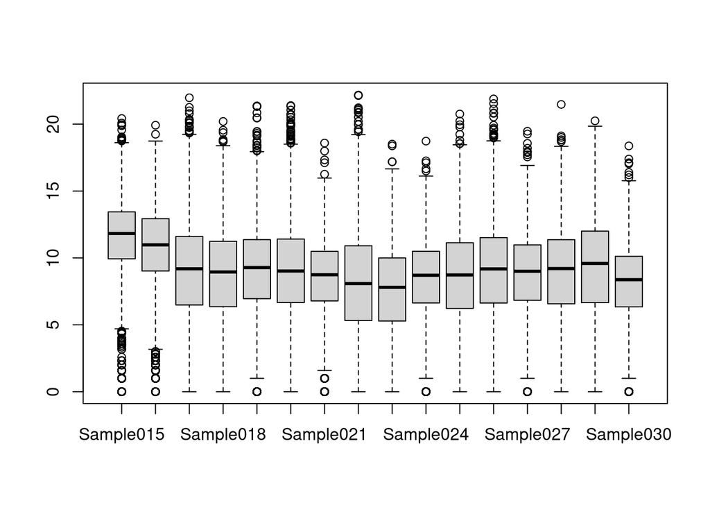

```r
#loading the gene expression data set and patient metadata
load("assess_data_1224.Rdata")

idx <- 20 #selecting/indexing gene 20 for analysis
c_cl <- 15:30 #selecting columns 15-30 (this shows the last 15 samples)

#creating a box plot log2-transformed of gene expression data
# +1 preserves zero counts that could be present in some genes as zero in log space
boxplot(log2(Y[, c_cl] + 1))
```

```r
x <- patient_data$tissue[c_cl]  ## Extracting tissue type information for the selected samples
z <- patient_data$patient[c_cl] ## Extracting patient ID information for the selected samples

## creating a data frame for regression analysis that contains :
## y : expression values for selected/indexed gene (idx) and samples
# x : tissue type
# z : patient ID
#lib_size : total counts per sample (the sum of the coloumn)
tmp <- data.frame(y = Y[idx, c_cl], x = x, z = z, lib_size = colSums(Y[, c_cl]))

## Fitting Poisson regression model :
## the response variable : gene expression (y)
### predictors : tissue type (x) , patient id (z), library size
out <- glm(y ~ x + z + lib_size, data = tmp, family = "poisson")

# Extracting the p-value for the tissue type coefficient. [2,4] selects the second and forth coloumn
p_val <- summary(out)$coefficients[2, 4]
```

# 2.1 Data Exploration

## Quality Control and identifying the problematic sample

The problematic sample in the data is Sample 003 which is a tumor tissue as from the produced box plot we can see that it has no gene expression distribution compared to all other samples. This can cause a biased differential expression analysis as this can introduce bias leading to false positives or false-negative results which can have a disproportionate effect on the statistical modles used for differential expression.

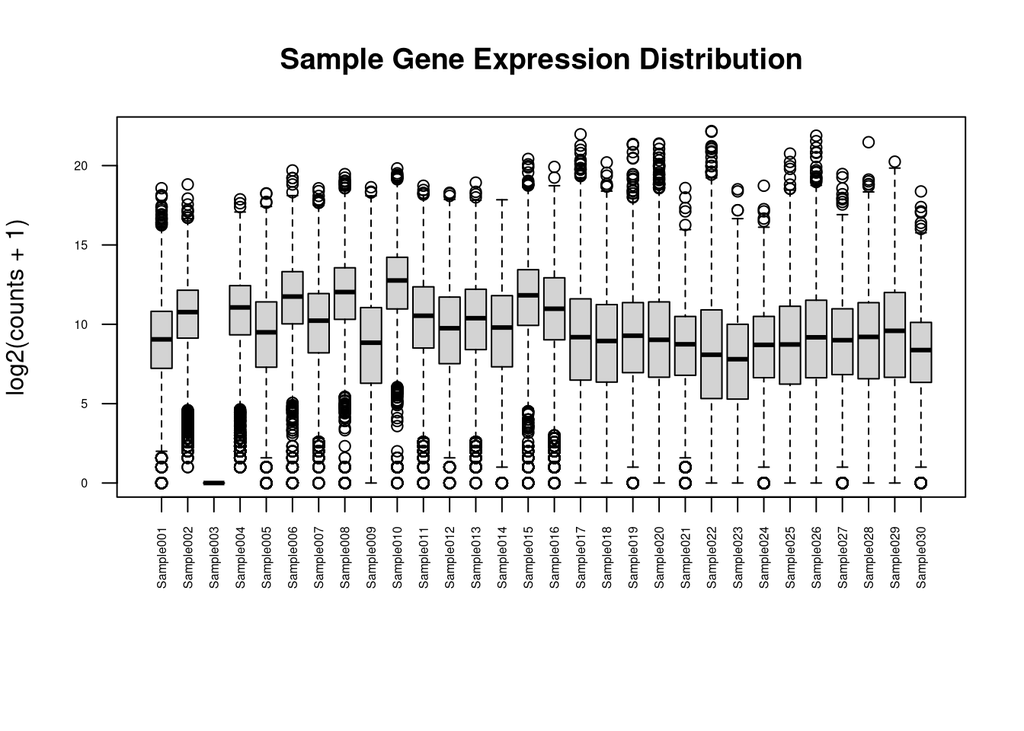

```r
load("assess_data_1224.Rdata")

lib_sizes <- colSums(Y)


#creating a data frame with sample information
sample_info <- data.frame(
   Sampple = 1:ncol(Y),
   LibSize = lib_sizes,
   Tissue = patient_data$tissue,
   Patient = patient_data$patient
)

## creating log-transformed box plot of the expression values
par(mar=c(8,4,4,2))
boxplot(log2(Y + 1), las=2,
        main="Sample Gene Expression Distribution",
        ylab="log2(counts + 1)",
        xlab="",
        cex.axis=0.5)
```

```r
## printing library size summary
print("Library Size Summary per Sample:")
```

```
## [1] "Library Size Summary per Sample:"
```

```r
print(sample_info)
```

```
##           Sampple  LibSize Tissue    Patient
## Sample001       1 13742459 Tumour  Patient.1
## Sample002       2 21727547 Tumour  Patient.2
## Sample003       3        0 Tumour  Patient.3
## Sample004       4 24118564 Tumour  Patient.4
## Sample005       5 18681490 Tumour  Patient.5
## Sample006       6 49912748 Tumour  Patient.6
## Sample007       7 24205111 Tumour  Patient.7
## Sample008       8 63516498 Tumour  Patient.8
## Sample009       9 19796342 Tumour  Patient.9
## Sample010      10 97008139 Tumour Patient.10
## Sample011      11 34211461 Tumour Patient.11
## Sample012      12 22062440 Tumour Patient.12
## Sample013      13 27817474 Tumour Patient.13
## Sample014      14 22794661 Tumour Patient.14
## Sample015      15 71128331 Tumour Patient.15
## Sample016      16 51065958 Normal  Patient.1
## Sample017      17 57171439 Normal  Patient.2
## Sample018      18 23442175 Normal  Patient.3
## Sample019      19 42218066 Normal  Patient.4
## Sample020      20 60236867 Normal  Patient.5
## Sample021      21  9463435 Normal  Patient.6
## Sample022      22 58378416 Normal  Patient.7
## Sample023      23  8565800 Normal  Patient.8
## Sample024      24  8830817 Normal  Patient.9
## Sample025      25 25801049 Normal Patient.10
## Sample026      26 53748186 Normal Patient.11
## Sample027      27 15287653 Normal Patient.12
## Sample028      28 25611629 Normal Patient.13
## Sample029      29 35339442 Normal Patient.14
## Sample030      30  7360767 Normal Patient.15
```

```r
# Identifying  potential outlier
outlier_sample <- which.min(lib_sizes)
print("\nSample with lowest library size:")
```

```
## [1] "\nSample with lowest library size:"
```

```r
print(sample_info[outlier_sample,])
```

```
##           Sampple LibSize Tissue   Patient
## Sample003       3       0 Tumour Patient.3
```

# 2.2 Expression Analysis

## Differential Expression

For the expression analysis, samples 3 and 18 will be removed as they are from the same patient. We have 30 samples and 15 patients. This means that each patient has two samples respectively. Since sample 3 identified to be the problematic sample, its paired sample (sample 18) needs to be excluded.Remainder is 28 samples for the analysis.

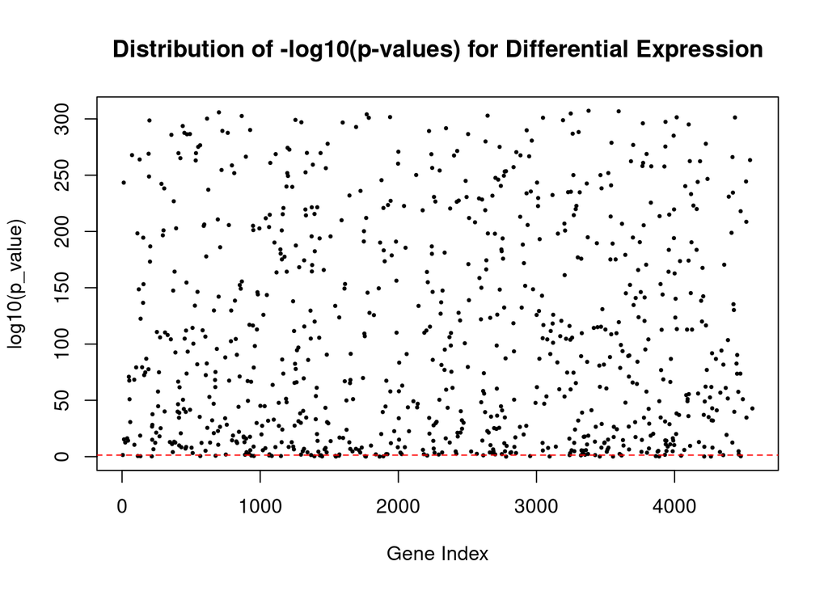

```r
#installing packages
library(tidyverse)
library(MASS)

#loading data
load("assess_data_1224.Rdata")


#removing the problematic sample pair (sample 3 and 18)
good_samples <- setdiff(1:ncol(Y), c(3,18))

#creating a vector to store the p-values for all the genes
p_values <- numeric(nrow(Y))

## creating a loop, For every gene we are preforming Poisson regression
for (idx in 1:nrow(Y)) {
  #creating data frame for current gene
  tmp <- data.frame(
    y = Y[idx, good_samples],
    x = patient_data$tissue[good_samples] #tissue type (normal/tumour)
  )

  ## fitting Poisson regression with tissue type only
  out <- glm(y ~ x, data = tmp, family = "poisson")

  #storing p-values for tissue effects
  p_values[idx] <- summary(out)$coefficients[2,4]
}


#creating a log10 plot for the p-values

plot(-log10(p_values),
     main="Distribution of -log10(p-values) for Differential Expression",
     ylab="log10(p_value)",
     xlab="Gene Index",
     pch=20,
     cex=0.5)

# if p-value = 0.05 then it is significant. we are adding a horizontal line at the significance threshold.
abline(h=-log10(0.05), col="red", lty=2)
```

```r
#printing the results
significant_genes <- sum(p_values < 0.05)
print(paste("Number of significantly differentially expressed genens:", significant_genes))
```

```
## [1] "Number of significantly differentially expressed genens: 4532"
```

## Differential Expression with Covariates

Performing a regression-based analysis to identify genes differentially expressed between normal and tumor samples including the tissue variable indicating if it is tumour or normal sample.

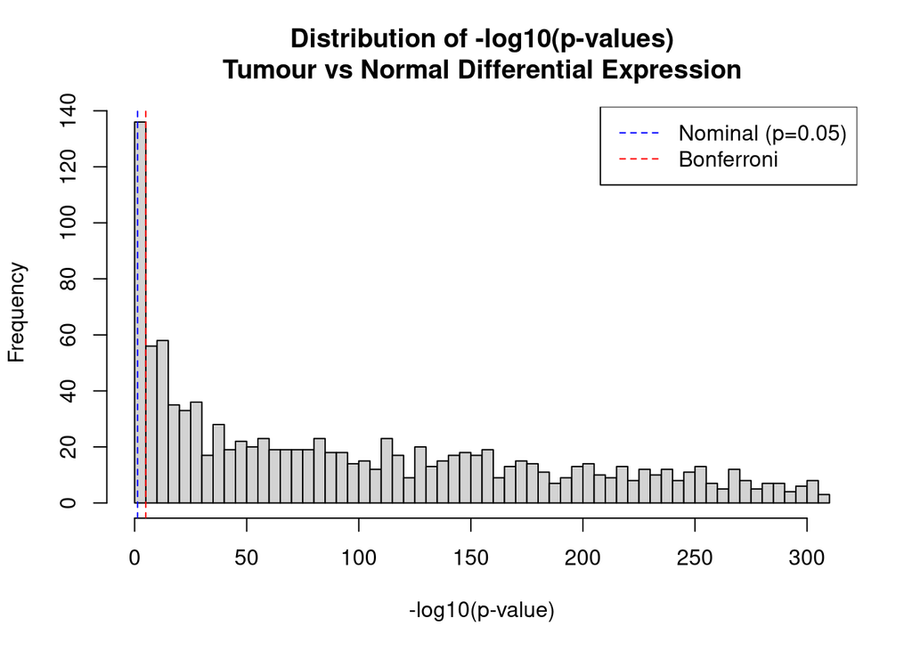

```r
# Removing problematic samples
good_samples <- setdiff(1:ncol(Y), c(3, 18))
Y_clean <- Y[, good_samples]
patient_data_clean <- patient_data[good_samples, ]

# Performing differential expression analysis
perform_de_analysis <- function(Y, patient_data) {
  n_genes <- nrow(Y)
  p_values <- numeric(n_genes)
  coefficients <- numeric(n_genes)

  for(i in 1:n_genes) {
    data <- data.frame(
      expression = Y[i,],
      tissue = factor(patient_data$tissue),
      patient = factor(patient_data$patient),
      lib_size = scale(colSums(Y))
    )

    # Creating a regression model including tissue type
    model <- glm(expression ~ tissue + patient + lib_size,
                data = data,
                family = "poisson")

    coef_summary <- summary(model)$coefficients
    tissue_idx <- grep("Tumour", rownames(coef_summary))
    p_values[i] <- coef_summary[tissue_idx, 4]
    coefficients[i] <- coef_summary[tissue_idx, 1]
  }

  return(list(p_values = p_values, coefficients = coefficients))
}

# Performing analysis
results <- perform_de_analysis(Y_clean, patient_data_clean)

# Plotting the -log10(p-values)
hist(-log10(results$p_values),
     main = "Distribution of -log10(p-values)\nTumour vs Normal Differential Expression",
     xlab = "-log10(p-value)",
     breaks = 50)

# Adding significance thresholds. p>/= 0.05 then it is statistically significant.
abline(v = -log10(0.05), col = "blue", lty = 2)
abline(v = -log10(0.05/nrow(Y_clean)), col = "red", lty = 2)
legend("topright",
       legend = c("Nominal (p=0.05)", "Bonferroni"),
       col = c("blue", "red"),
       lty = 2)
```

```r
# Printing number of significant genes
print(paste("Number of significantly differentially expressed genes (FDR < 0.05):",
           sum(p.adjust(results$p_values, method = "BH") < 0.05)))
```

```
## [1] "Number of significantly differentially expressed genes (FDR < 0.05): 4510"
```

Comparison of p-values with and without inclusion of the tissue type as co-variate. Patient ID and library size have been used as other covariates.

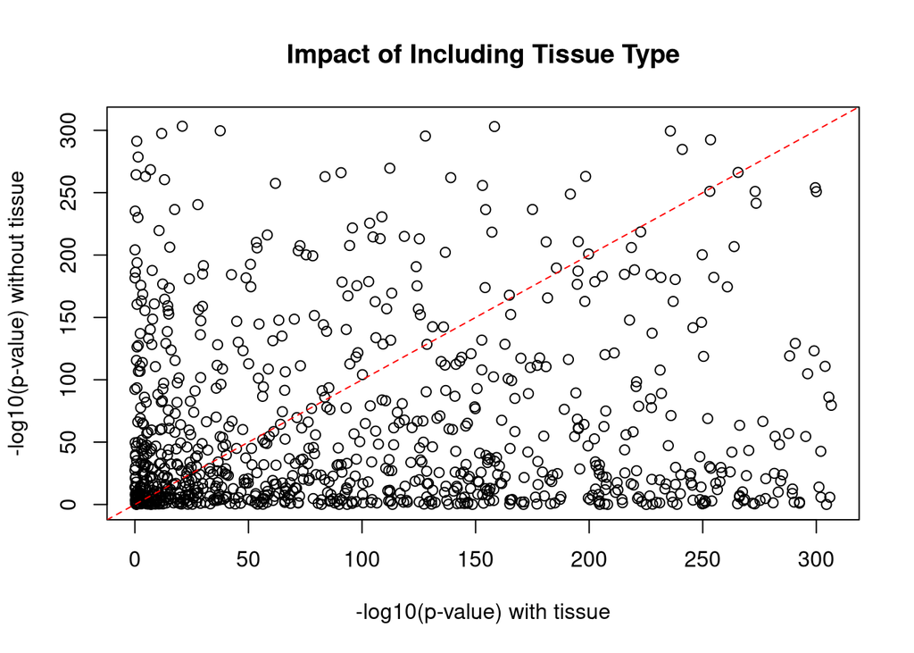

```r
# Removing problematic samples
good_samples <- setdiff(1:ncol(Y), c(3, 18))
Y_clean <- Y[, good_samples]
patient_data_clean <- patient_data[good_samples, ]

# creating a model for comparison
compare_models <- function(Y, patient_data) {
  n_genes <- nrow(Y)
  p_values_with <- numeric(n_genes)
  p_values_without <- numeric(n_genes)
  effect_sizes <- matrix(NA, nrow=n_genes, ncol=3)
  colnames(effect_sizes) <- c("Tissue", "Patient", "Library Size")

  for(i in 1:n_genes) {
    data <- data.frame(
      expression = Y[i,],
      tissue = factor(patient_data$tissue),
      patient = factor(patient_data$patient),
      lib_size = scale(colSums(Y))
    )

    # Models
    model_with <- glm(expression ~ tissue + patient + lib_size, ## with tissue
                     data = data, family = "poisson")
    model_without <- glm(expression ~ patient + lib_size, ## without tissue type
                        data = data, family = "poisson")

    # finding out the p-values
    coef_with <- summary(model_with)$coefficients
    p_values_with[i] <- coef_with[grep("Tumour", rownames(coef_with)), 4]
    p_values_without[i] <- summary(model_without)$coefficients[2, 4]

    # Get effect sizes
    effect_sizes[i, "Tissue"] <- abs(coef_with[grep("Tumour", rownames(coef_with)), 1])
    effect_sizes[i, "Patient"] <- mean(abs(coef_with[grep("Patient", rownames(coef_with)), 1]))
    effect_sizes[i, "Library Size"] <- abs(coef_with["lib_size", 1])
  }
  return(list(p_with=p_values_with, p_without=p_values_without, effects=effect_sizes))
}

results <- compare_models(Y_clean, patient_data_clean)

# Plotting the comparisons of p-values
plot(-log10(results$p_with), -log10(results$p_without),
     xlab="-log10(p-value) with tissue",
     ylab="-log10(p-value) without tissue",
     main="Impact of Including Tissue Type")
abline(0,1, col="red", lty=2)
```

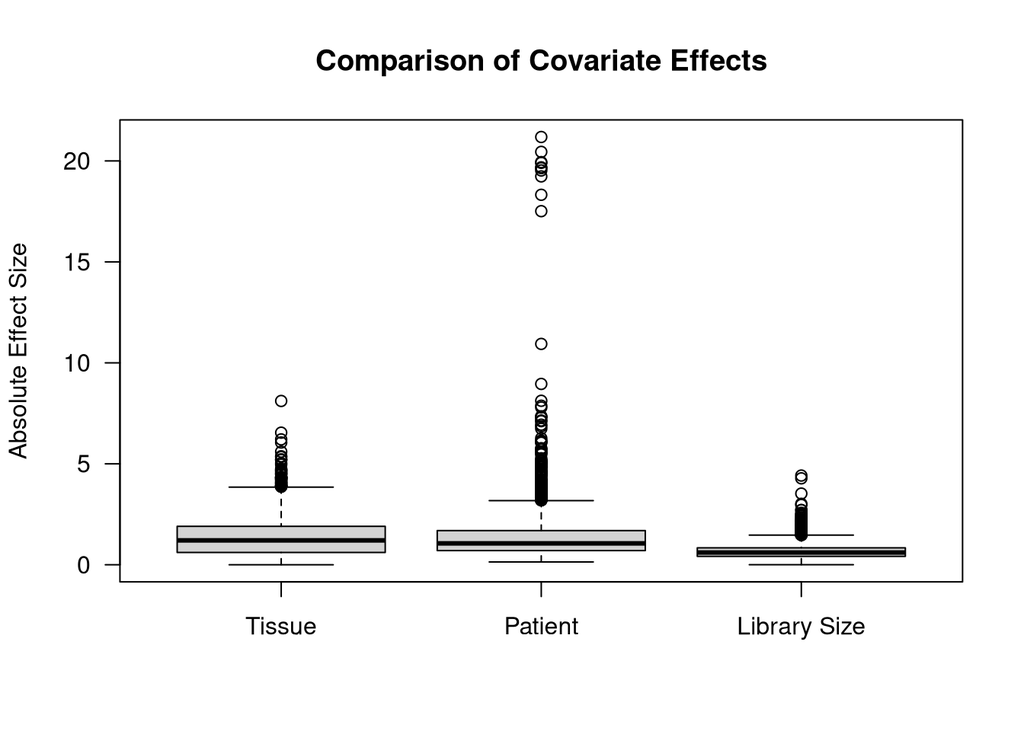

```r
# Plotting effect sizes
boxplot(results$effects,
        main="Comparison of Covariate Effects",
        ylab="Absolute Effect Size",
        las=1)
```

```r
# Printing mean effect sizes
print("Mean absolute effect size of each covariate:")
```

```
## [1] "Mean absolute effect size of each covariate:"
```

```r
print(colMeans(results$effects))
```

```
##       Tissue      Patient Library Size
##    1.3445427    1.3677894    0.6584818
```

## Obervations from the results

The “Impact of including Tissue type” scatter plot has a red diagonal red line which is used as a reference line for when the -log10(p-values) are equal in both with and without tissue type as covariate in the analysis. The points below the line show that genes are less significant when tissue type is removed. The plot shows that many points fall below the line especially with -log10(p-value)> 100. This suggests that using tissue type as a covariate increases significance in the differential expression.

From the “Mean absolute effect size of each covariate:” The mean for patients : 1.368 , tissue : 1.345 , and Library size : 0.658. From this we can see patients have the biggest effect as a covariate.

Overall, from the result we can deduce that Patient ID has the biggest effect as a covariate. It is important to note that the difference is very small compared to the tissue type (deduced from the mean). This suggests that both patient variation and tissue type are important factors in gene expression.

## Interpretation

From the results of the differential expression analysis, there is a big difference between tumor and normal tissue sample as there are 4510 genes that are significantly different. When tissue type was included in the analysis it improved the ability to detect these differences and this is shown by the increased significance in the scatter plot. Both Patient variation and tissue type have similar strong effects (means : 1.368 and 1.345), whilst the library size showed a smaller mean effect of 0.658. From a biological perspective, this is expected as the library size only accounts for a technical variation in terms of sequencing depth. However, patient variances and tissue type represents real biological variation in gene expression.

###### Note: AI tools (Humata and Claude) were used to help and provide guidance with some of the codes generated.